# Predicting Flight Delays

Stat 253

Rishika Kundu & Lilabeth Sokolewicz

# Research Goals

Briefly describe your goals for this report. Provide some context to understand your goals.

Flying today is a stressful process, often aggravated by indefinite wait times - in security, during boarding, and on the tarmac, among others. When one is on a tight schedule, it can be helpful to anticipate some of the delays in this process. Therefore, our goal in this report is to use the tools of statistical machine learning to build a model that will predict how late any flight leaving Minneapolis / St. Paul airport (MSP) will reach its destination.

# Data

Briefly describe your training data. You may use 1 visualization in this section.

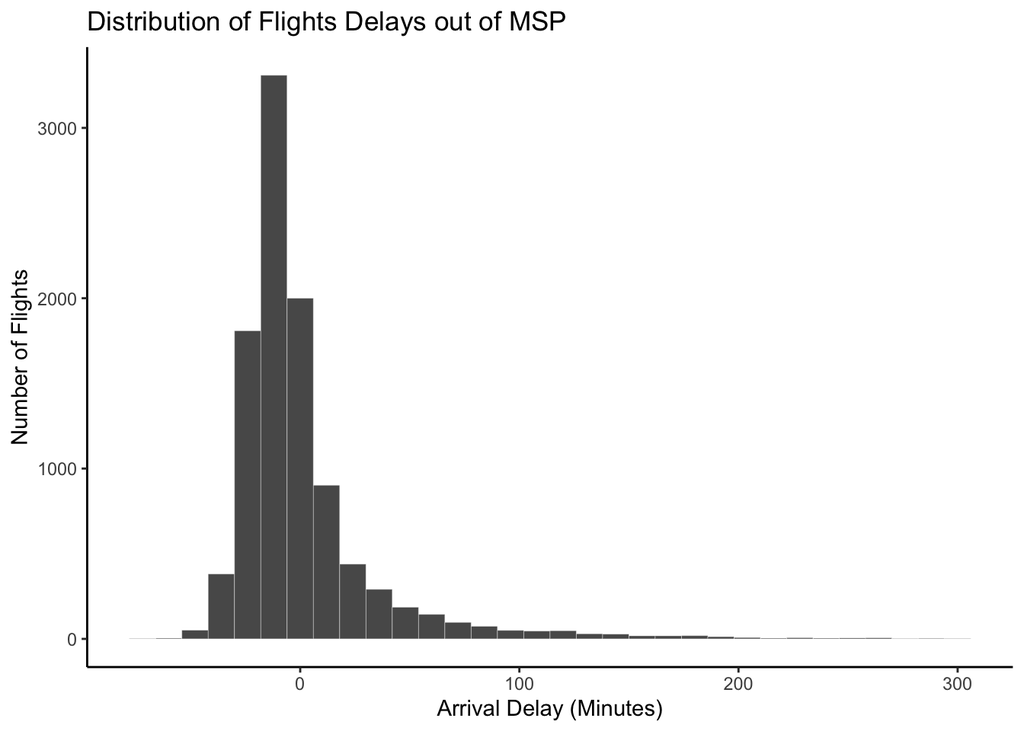

# Model Building

Describe the process by which you came up with the final model. This does not include every step you took but rather the final path your group decided on to build a model.

Since we had many possible predictors, we began by constructing a linear regression LASSO model to select the best predictors with which to predict our outcome, arrival delays. To clean the data, we removed certain variables from the variable recipe. These variables included those with only one value, like orgin of the flight, those intended to be distinct identifiers, such as flight number, and those irrelevant to prediction of arrival delay, like time zone. Utilizing trial-and-error, we determined a range of lambda values that included the one that produced the lowest cross-validation mean absolute error (CV MAE). To ensure this, we generated a plot to compare the CV MAEs across 50 LASSO models, each using a distinct lambda value. We concluded that the range of $10^{-5}$ to $10^{-.1}$ with 50 LASSO models included the optimal lambda value with the lowest MAE, 19.7. We also collapsed some of the less common destinations into an ‘other’ category since there were so many of them.

We further opted for the parsimonious penalty, which prioritizes the inclusion of as few predictors as possible while maintaining model efficacy. Fewer predictors allow for a more interpretable and better model. Additionally, we also constructed a more flexible non-parametric GAM model to accommodate any underlying behavior in the predictor variables. However, the CV MAE derived from the GAM model was 20.7, higher than the value obtained through LASSO. The GAM model was also computationally intensive and took very long to run even after removing most of the predictors. Given the inefficiency of the GAM model in handling numerous predictors and its higher MAE, we ultimately decided to proceed with the LASSO model.

# Implementation

We used tidymodels to implement this model building process. See code below for full details.

**View Code**

```r
lasso_spec <- linear_reg() %>%
  set_mode("regression") %>%
  set_engine("glmnet") %>%
  set_args(mixture = 1, penalty = tune())

variable_recipe <- recipe(arr_delay ~ ., data = flights) %>%
  step_rm(
    year,
    origin,
    tailnum,
    dest_dst,
    dest_name,
    plane_model,
    plane_engines,
    time_hour,
    dest_tzone,
    plane_type,
    plane_year,
    date,
    flight
  ) %>%
  step_other(dest, threshold = 0.01) %>%
  step_dummy(all_nominal_predictors())



lasso_workflow <- workflow() %>%
  add_recipe(variable_recipe) %>%
  add_model(lasso_spec)

fit(lasso_workflow, data = flights)
```

```
## ══ Workflow [trained] ══════════════════════════════════════════════════════════
## Preprocessor: Recipe
## Model: linear_reg()
##
## ── Preprocessor ────────────────────────────────────────────────────────────────
## 3 Recipe Steps
##
## • step_rm()
## • step_other()
## • step_dummy()
##
## ── Model ───────────────────────────────────────────────────────────────────────
##
## Call:  glmnet::glmnet(x = maybe_matrix(x), y = y, family = "gaussian",      alpha = ~1)
##
```

[output cut: 50 more lines]

```r
set.seed(253)
lasso_models <- lasso_workflow %>%
  tune_grid(
    grid = grid_regular(penalty(range = c(-5, -.1)), levels = 50),
    resamples = vfold_cv(flights, v = 10),
    metrics = metric_set(mae)
  )

collect_metrics(lasso_models)
```

```
## # A tibble: 50 × 7
##      penalty .metric .estimator  mean     n std_err .config
##        <dbl> <chr>   <chr>      <dbl> <int>   <dbl> <chr>
##  1 0.00001   mae     standard    19.8    10   0.192 Preprocessor1_Model01
##  2 0.0000126 mae     standard    19.8    10   0.192 Preprocessor1_Model02
##  3 0.0000158 mae     standard    19.8    10   0.192 Preprocessor1_Model03
##  4 0.0000200 mae     standard    19.8    10   0.192 Preprocessor1_Model04
##  5 0.0000251 mae     standard    19.8    10   0.192 Preprocessor1_Model05
##  6 0.0000316 mae     standard    19.8    10   0.192 Preprocessor1_Model06
##  7 0.0000398 mae     standard    19.8    10   0.192 Preprocessor1_Model07
##  8 0.0000501 mae     standard    19.8    10   0.192 Preprocessor1_Model08
##  9 0.0000631 mae     standard    19.8    10   0.192 Preprocessor1_Model09
## 10 0.0000794 mae     standard    19.8    10   0.192 Preprocessor1_Model10
## # ℹ 40 more rows
```

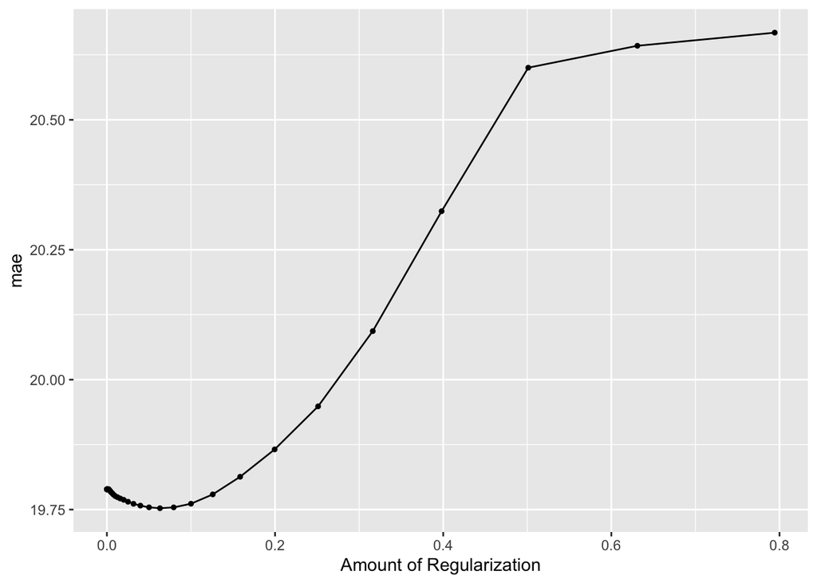

```r
autoplot(lasso_models) +
  scale_x_continuous()
```

```r
parsimonious_penalty <- lasso_models %>%
  select_by_one_std_err(metric = "mae", desc(penalty))

parsimonious_penalty
```

```
## # A tibble: 1 × 9
##   penalty .metric .estimator  mean     n std_err .config            .best .bound
##     <dbl> <chr>   <chr>      <dbl> <int>   <dbl> <chr>              <dbl>  <dbl>
## 1   0.200 mae     standard    19.9    10   0.177 Preprocessor1_Mod…  19.8   19.9
```

```r
final_lasso_model <- lasso_workflow %>%
  finalize_workflow(parameters = parsimonious_penalty) %>%
  fit(data = flights)
```

# Model Evaluation

Evaluate your final model based on the four questions: Is it strong? Is it good? Is it accurate in predictions? Is it fair? Include evidence to support your answers. You may use up to 3 visualizations in this section.

Is it fair?

It is important to consider the context of data collection and the potential impact of our analysis. Since the data was likely self-reported by carriers, it is possible that the airlines manipulated their data to appear more reliable to fliers. The model we created could also be manipulated and used competitively by airlines to claim that certain airlines cause more delays than others.

Is it accurate in predictions?

```r
final_lasso_model %>%
  augment(new_data = flights) %>%
  mutate(.resid= arr_delay -.pred) %>%
  summarize(mae = mean(abs(.resid)))
```

```
## # A tibble: 1 × 1
##     mae
##   <dbl>
## 1  19.7
```

We expect the average predicted delay in arrival to be off by 19.7 minutes from the actual observed arrival delay. This is a relatively high number especially given that the majority of arrival delays in the dataset are closer to 0 minutes. However, contextually speaking, a delay in roughly 20 minutes from a flight is not unexpected and could be considered acceptable.

Is it strong?

```r
final_lasso_model %>%
  augment(new_data = flights) %>%
  rsq(truth = arr_delay, estimate = .pred)
```

```
## # A tibble: 1 × 3
##   .metric .estimator .estimate
##   <chr>   <chr>          <dbl>
## 1 rsq     standard      0.0945
```

The model accounts for 9 percent of the variability in the arrival delay. This suggests that the model has limited explanatory power since it does not capture a significant portion of the variation in arrival delays. However, since arrival delay is highly variable and is influenced by many predictors, our model being able to predict roughly 10 percent of the variability is also significant. Thus, given the nature of arrival delay, accounting for 10 percent of its variability makes the model relatively strong.

```r
all_lassos <- final_lasso_model %>%
  extract_fit_parsnip() %>%
  pluck("fit")


COEF_LAMBDA <- all_lassos$beta  %>%
  as.matrix() %>%
  t() %>%
  as.data.frame() %>%
  mutate(lambda = all_lassos$lambda ) %>%
  pivot_longer(cols = -lambda,
               names_to = "term",
               values_to = "coef")



COEF_LAMBDA %>% filter(lambda > 2, coef != 0 )
```

```
## # A tibble: 14 × 3
##    lambda term                 coef
##     <dbl> <chr>               <dbl>
##  1   4.06 visib          -0.238
##  2   3.70 visib          -0.455
##  3   3.37 visib          -0.653
##  4   3.07 visib          -0.834
##  5   2.80 wind_speed      0.0427
##  6   2.80 visib          -0.997
##  7   2.55 wind_speed      0.0894
##  8   2.55 visib          -1.15
##  9   2.33 sched_dep_time  0.0000141
## 10   2.33 wind_speed      0.132
## 11   2.33 visib          -1.28
## 12   2.12 sched_dep_time  0.000381
## 13   2.12 wind_speed      0.162
## 14   2.12 visib          -1.41
```

Further, the model keeps several predictors even at high lambda values, highlighting the strength of visibility and wind speed in our prediction of arrival delay.

Is it good?

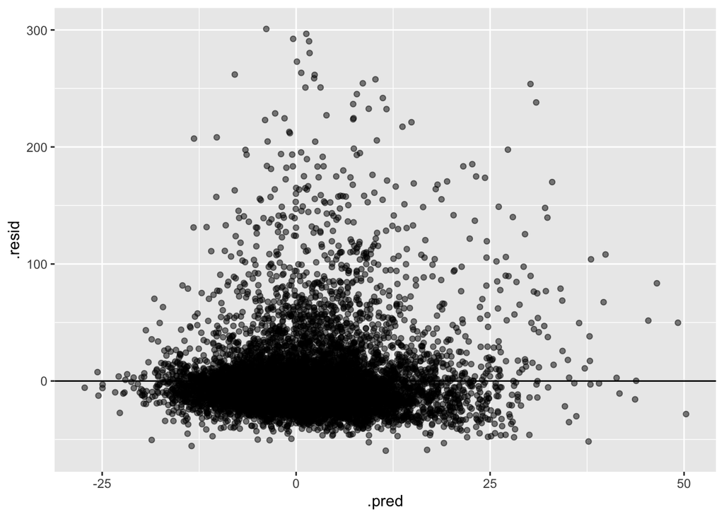

```r
final_lasso_model %>%
  augment(new_data = flights) %>%
  mutate(.resid= arr_delay -.pred) %>%
  ggplot(aes(x = .pred, y = .resid)) +
  geom_point(alpha = .5) +
  geom_hline(yintercept = 0)
```

To evaluate whether our model is good or not, we created a residual plot. The model does not cut through the center of the data, indicating potential issues with the model being imbalanced above and below zero. The data points are further clustered near the line of 0 residuals with more data points above 0 towards the center of the span of the model. Although the distribution of data points appears somewhat random, a rough triangular shape can be observed with the data, suggesting the presence of an underlying trend.

Therefore, our model is good at predicting delays of flights within one hour. However, for flights with delays above an hour, it is hard to predict the arrival delay. This may be because the majority of the dataset has low arrival delay times clustered around 0 minutes of delay (as explored in the histogram). To improve the model, a larger dataset with flights that have been delayed further would be useful.

The model also has limitations highlighted by its relatively higher CV MAE of roughly 20 minutes. Yet considering the complexity of the dataset with numerous variables and our resource constraints, the model performs adequately in predicting arrival delays. The accuracy and strength of the model could be further improved by including variables such as weather conditions at the destination.

Thus, although further improvements could be made to the model, it does a good job of predicting arrival delays of up to 60 minutes.

# Contributions

Lilabeth wrote the research goals and the context of the data. She also made the histogram. Both of us worked on creating the final LASSO model and writing the model building. Lilabeth made the GAM model. Rishika wrote the model evaluation and created the residual plot. We collaboratively worked on all parts and took each other’s input.

# Validation

```r
Flights_Test <- read_csv('Flights_Test.csv')

final_lasso_model %>%
  augment(new_data = Flights_Test) %>%
  mae(truth = arr_delay, estimate = .pred)
```

```
## # A tibble: 1 × 3
##   .metric .estimator .estimate
##   <chr>   <chr>          <dbl>
## 1 mae     standard        19.8
```